# Fuel Prices From 2003 to 2023

Anonymous

2023-05-09

## Research Question

With recent unprecedented increases in the price of fuel worldwide, it prompted the question of how have fuel prices for petrol and diesel changed in the last 20 years within the UK? Fuel prices have a wide impact on many aspects of life and are a useful indicator for the state of a country’s economy.

## Data Origins

```r
raw_data <- read_excel(here('Data','Weekly_Fuel_Prices.xlsx'), #loading data
                       skip=7, #skipping first 7 lines
                       sheet='All years') #selecting sheet titled "All Years"
```

Due to formatting of the Excel workbook I skipped the first 7 lines of the sheet in order for the data to load correctly and specify the page of the workbook I wanted data to be loaded from.

Raw Data

[output not shown]

Link to [National Statistics Weekly Road Fuel Prices](https://www.gov.uk/government/statistics/weekly-road-fuel-prices)*

## Data Preparation

```r
#create clean_data
clean_data <- raw_data %>%

#rename variables ULSP and ULSD to Petrol and Diesel
  rename("Petrol"="ULSP:  Pump price (p/litre)",
         "Diesel"="ULSD: Pump price (p/litre)") %>%

#select only variables date, Diesel and Petrol
  select(Date,Petrol,Diesel)
```

Then I converted the data frame to long format.

```r
df <- pivot_longer(clean_data,-Date, names_to="Cat", values_to="Value")
```

Processed Data

| Date | Cat | Value |
| --- | --- | --- |
| 2003-06-09 | Petrol | 74.59028 |
| 2003-06-09 | Diesel | 76.77339 |
| 2003-06-16 | Petrol | 74.46914 |
| 2003-06-16 | Diesel | 76.68905 |
| 2003-06-23 | Petrol | 74.42357 |
| 2003-06-23 | Diesel | 76.62055 |

## Visualisation

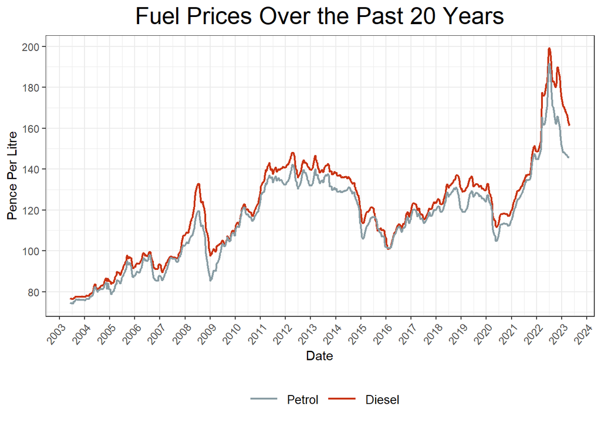

```r
plot1 <- ggplot(df, aes(x=Date,y=Value,colour=Cat))+
  geom_line(linewidth=0.75)+

#titles and legends
  labs(title="Fuel Prices Over the Past 20 Years",x="Date",y="Pence Per Litre",color=NULL)+

#assign colours to Petrol and Diesel
  scale_color_manual(limits=c("Petrol","Diesel"),values=wes_palette("Royal1",n=2))+

#adjust scale breaks
  scale_x_datetime(date_breaks="1 year",date_labels="%Y")+
  scale_y_continuous(breaks=c(80,100,120,140,160,180,200))+

#changing position and size of legends and labels
  theme_bw()+
  theme(axis.text.x=element_text(angle=50,hjust=1),
        legend.position = "bottom",
        plot.title=element_text(size=20,hjust=0.5),
        legend.text=element_text(size=10),
        legend.key.size=unit(1,"cm"))

#save output
ggsave("Fuel Prices 2003-2023.pdf", plot1, path=here("Plots"))
```

## Discussion

1. Fuel prices in 2022 were the highest they have been within the last 20 years
2. Price of fuel has been decreasing through 2023

Next time with more data and time, I would investigate potential relationships between fuel prices and other factors such as government party in power. I would also include a measure of inflation to create a relative baseline.